# Informe Primer Semestre 2021

Educación Física

Claudio Rojas. Director Académico

2021-07-31

## 0.1 Presentación

El presente informe tiene como objetivo revisar el trabajo del sector, a través de información que sistematiza los resultados académicos del I semestre y recoge lo proyectado para el II semestre del presente año. Además, consideran las definiciones claves que tenemos como colegio pero también como institución de la Compañía de Jesús.

Los apartados del informe son:

- Definiciones Claves
- Informe de Notas
- Metas de Aprendizaje.
- Propuestas de Evaluación II Semestre.
- Sugerencias para la planificación de las unidades 2 y 3.

Cada una de las partes de informe incluye sugerencias que buscan orientar la reflexión y práctica del sector para poder realizar los ajustes que sean necesarios para el logro de los aprendzajes que sean definidos.

## 0.2 Definiciones Claves

Les recuerdo tener presente las definiciones claves tanto a nivel de red ignaciana como interna que deben siempre orientar nuestro trabajo académico.

### 0.2.1 Envío 3 Planificación Estratégica de los colegios Jesuitas

Asegurar que los 10 colegios y escuelas jesuitas desarrollen las prácticas y procesos necesarios para ofrecer la excelencia académica propia de una comprensión ignaciana de la educación de calidad.

### 0.2.2 Nuestra Definición de Calidad

Nosotros, como comunidad sanjavierina, entendemos por educación de calidad todo aprendizaje que nos lleva a descubrir y desarrollar nuestras capacidades de manera integral, formándonos como personas competentes, conscientes, comprometidas, compasivas y creativas, para así conocer y amar más y mejor a Jesucristo, sirviendo a nuestros hermanos en los diversos contextos sociales.

### 0.2.3 Nuestro Foco de Mejora

Fortalecer la propuesta curricular, con una didáctica renovada, bajo el Paradigma Pedagógico Ignaciano.

## 0.3 Informe de Notas

El informe de notas contiene la siguiente información:

- Tabla de Resumen de las notas por nivel.
- Notas de 1º básico a IVº medio.
- Distribución por Logro por cada uno de los Niveles (Cursos)

En el caso de los resultados, les sugiero analizar:

- Los promedios finales obtenidos por cada nivel
- Cantidad de estudiantes que están en cada nivel de logro.
- Las diferencias de resultados entre hombres y mujeres.

### 0.3.1 Tabla Resumen de Notas:

Esta tabla incluye la información de la asignatura por nivel en cuanto:

- Promedio de la asignatura.
- Nota Mínima.
- Mediana.
- Nota Máxima.

[output not shown]

### 0.3.2 Notas de 1º básico a IVº medio

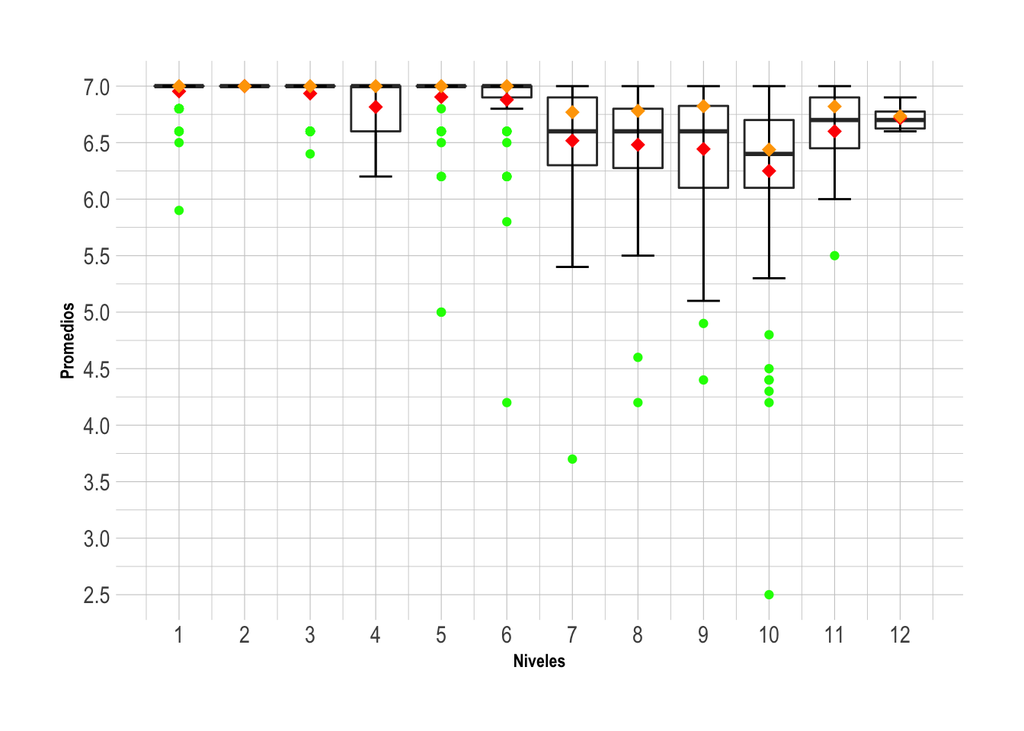

### 0.3.3 Distribución de Estudiantes por Niveles de Logro y diferenciado por Sexo.

#### 0.3.3.1 Primeros Básicos

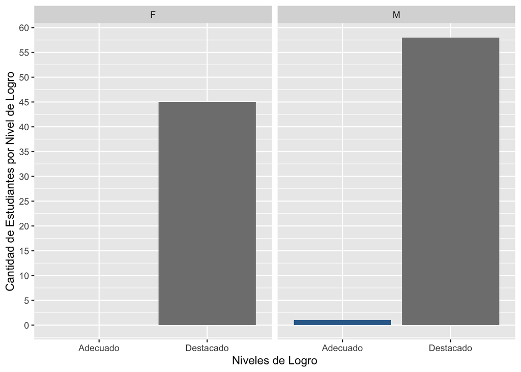

#### 0.3.3.2 Segundos Básicos

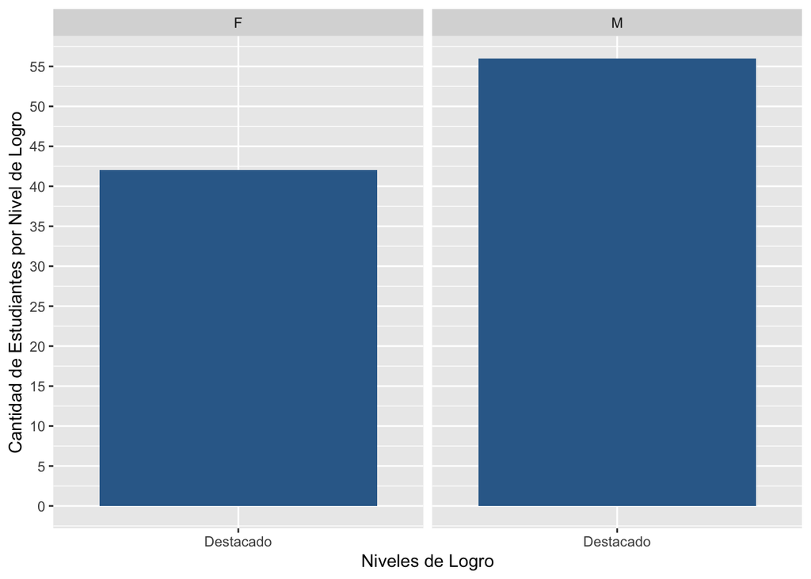

#### 0.3.3.3 Terceros Básicos

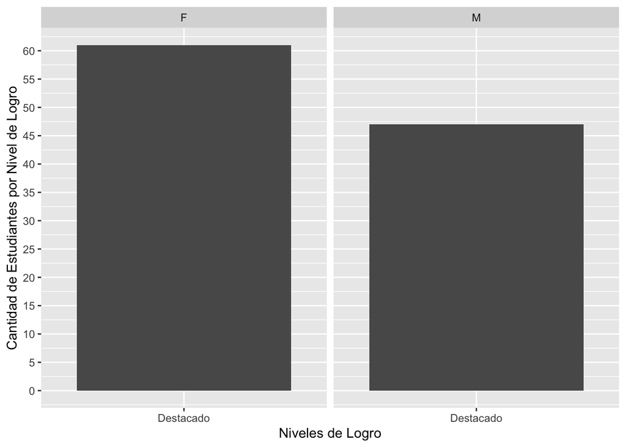

#### 0.3.3.4 Cuartos Básicos

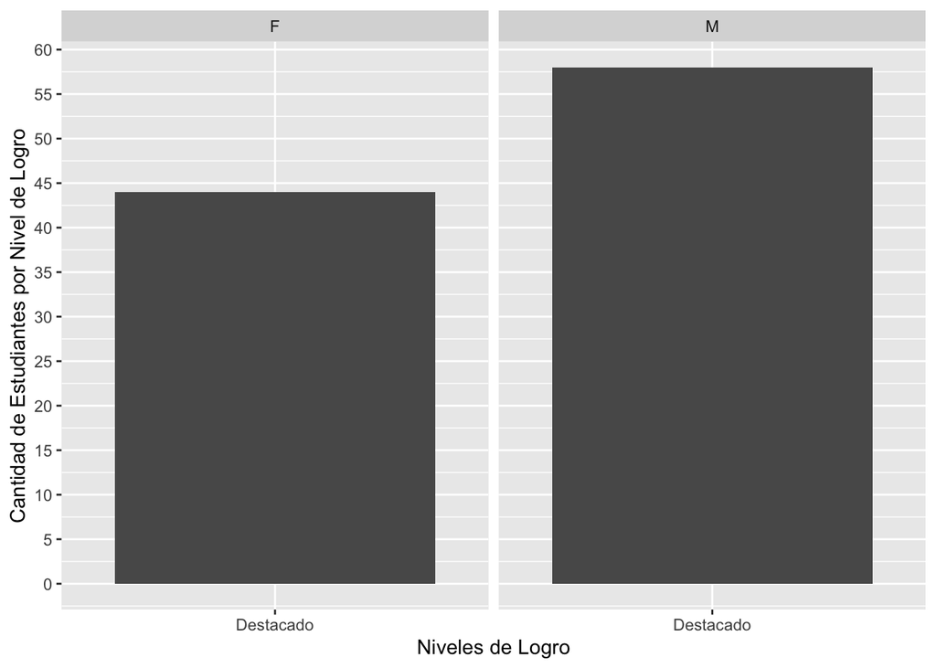

#### 0.3.3.5 Quintos Básicos

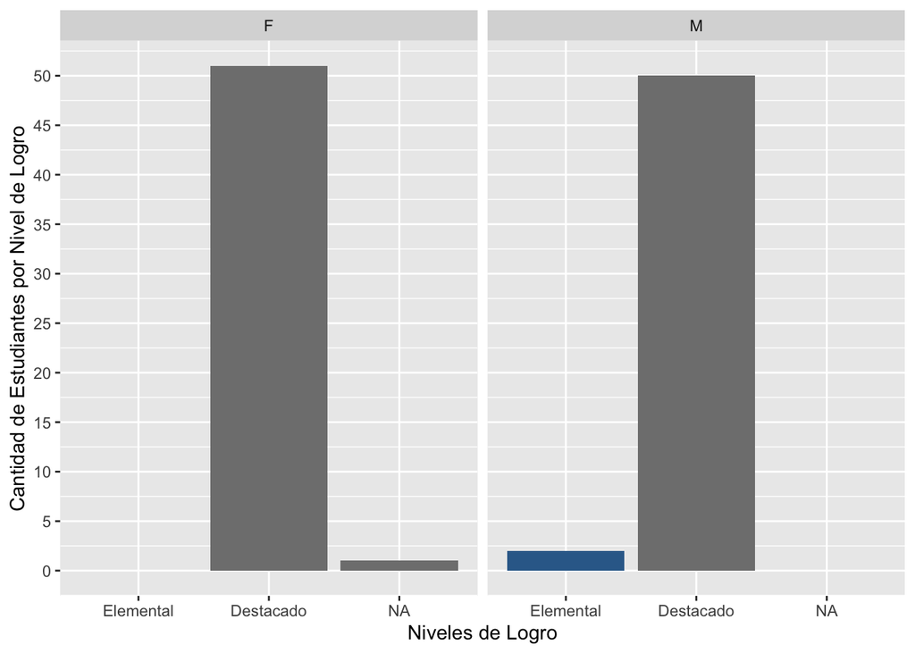

#### 0.3.3.6 Sextos Básicos

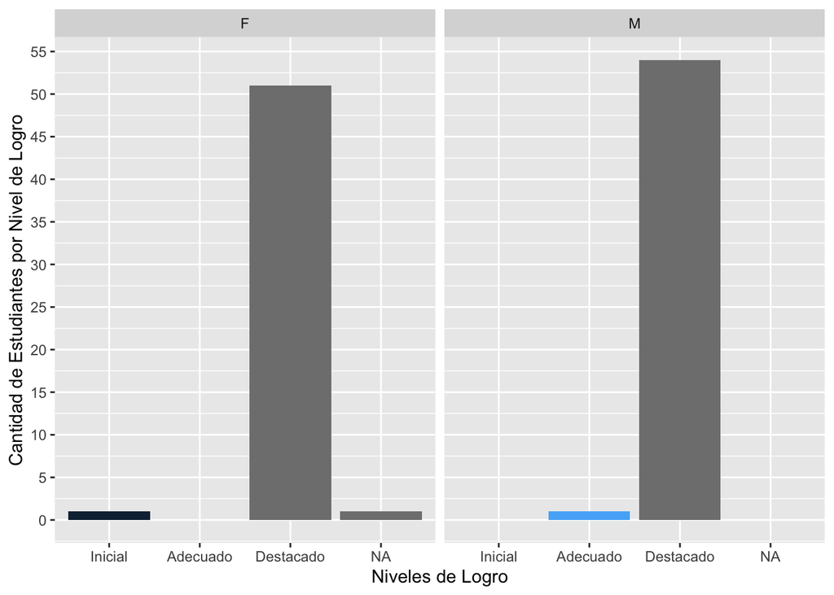

#### 0.3.3.7 Séptimos Básicos

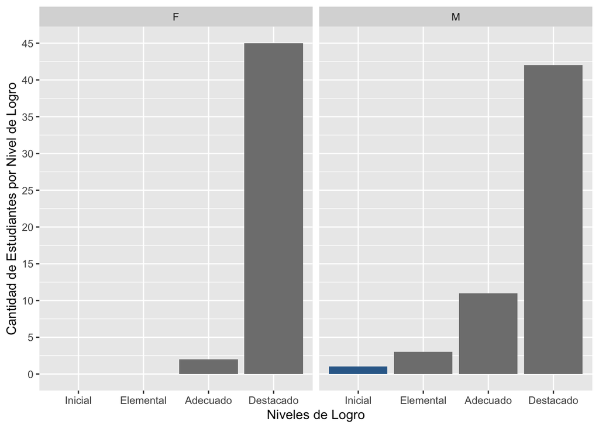

#### 0.3.3.8 Octavos Básicos

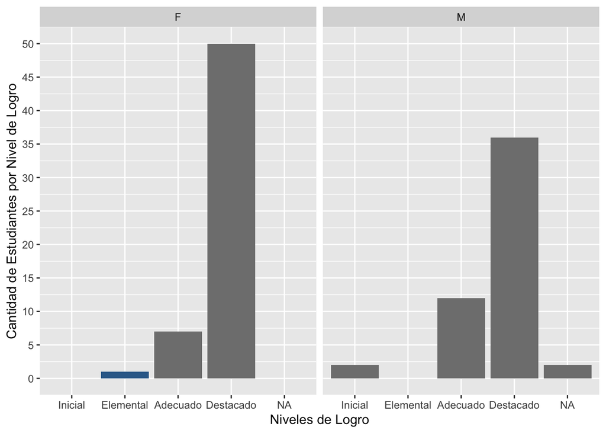

#### 0.3.3.9 Iº Medios

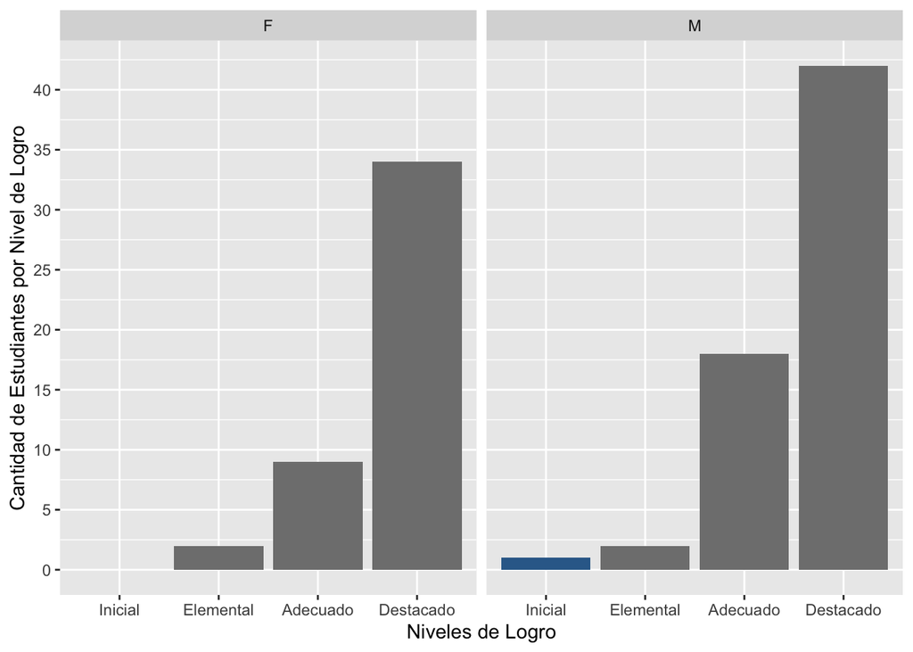

#### 0.3.3.10 IIº Medios

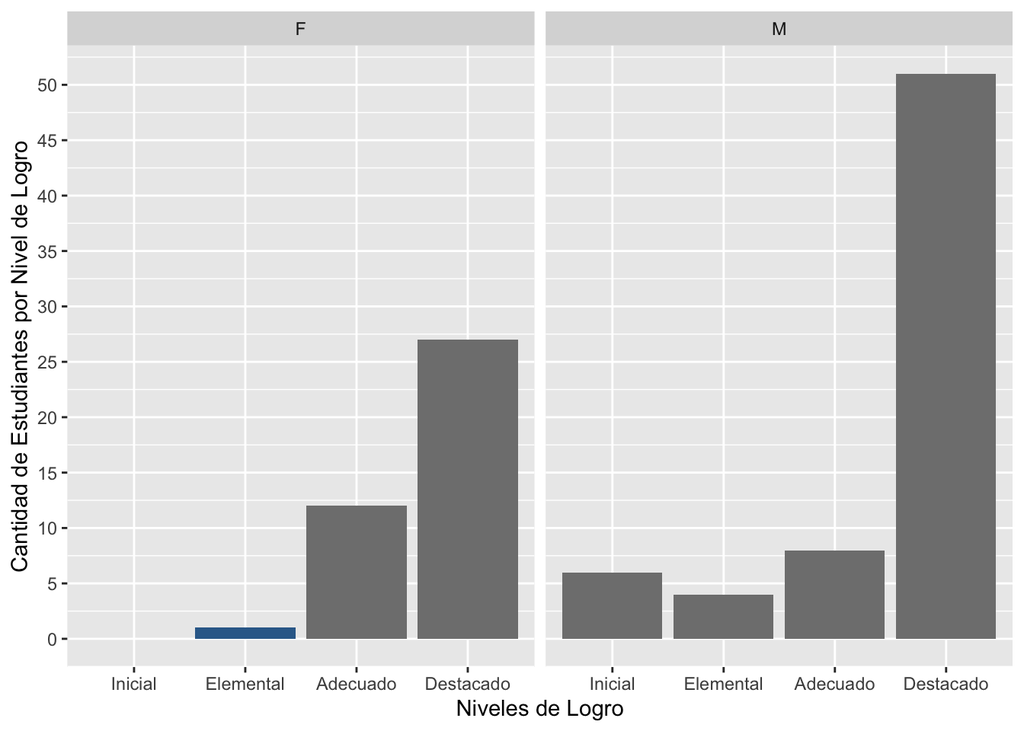

#### 0.3.3.11 IIIº - IVª Medios

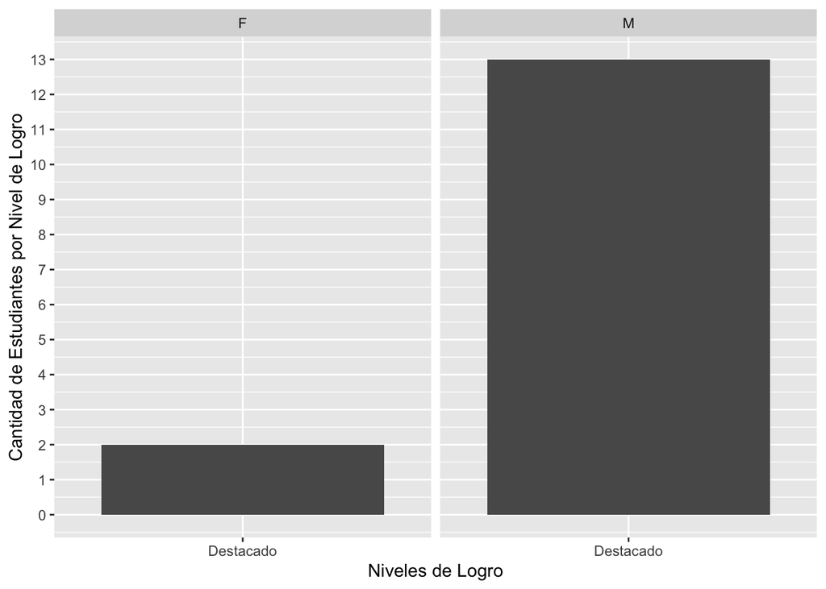

## 0.4 Metas de Aprendizajes

Se presentan las metas declaradas por el sector para todos los niveles en que se implementa. Ajustar las metas considerando los siguientes criterios:

- **¿Contienen errores gramaticales:** **Redacción, Faltas de Ortografía** **?**
- **¿Están escritas de manera clara y precisa?** Ejemplo: *“Aplicar sus habilidades específicas en el deporte colectivo voleibol. ejecutando técnica de golpe de dedos y antebrazos, se realizará la preparación durante 12 clases, en busqueda de una mejora en la tecnica de los siguientes golpes:a) Deben lanzar el balón, golpear con dedos y pasar por sobre el elástico. b)Deben lanzar el balón, golpear con antebrazos y pasar por sobre el elástico.c)Se agrega la dificultad de combinar ambos gestos”*. **En este caso y otros hay una mezcla de meta con descripción de OA y evaluación. La meta debe englobar.**
- **¿Se usan los verbos adecuados?** Ejemplo: *“Conocer y practicar diferentes tipos de cueca como…”.* **Priorizar verbos que engloben más que una secuencia de éstos y que sean verbos que se puedan medir con claridad**
- **¿Dan cuenta de aprendizajes relevantes que deben adquirir mis estudiantes?** Ejemplo: **“Describir y registrar las respuestas corporales provocadas por la práctica de actividad física a través de una escala de percepción” (Tercero Básico):** **En este caso, es una meta o es parte del proceso para llegar a una meta. Revisar este tipo de metas.**
- **¿Las metas diseñadas son coherentes y pertinentes con el plan de estudios de la asignatura?**
- **Hay metas que son bastantes similares como las de** **7º y 8º básico** **donde no queda tan claro la gradualidad de un año a otro.**
- **Ajustar las metas que contengan verbos que son poco precisos a la hora de medir:** *Comprender, Reflexionar*. **Pero también, aquellas que contengan verbos que den cuenta de niveles básicos de aprendizaje:** *Identificar, Reconocer*. **Las metas de aprendizajes deben ser** *Medibles* **pero también** *Desafiantes*.

### 0.4.1 Metas de Aprendizajes Primer Ciclo

| Nivel | Segunda Unidad | Tercera Unidad |
| --- | --- | --- |
| Play Group | Ejecutar diferentes equilibrios con distintos desplazamientos, posturas y movimientos a traves de circuitos y juego. | Desarrollar la ubicación espacial y temporal, tales como: adelante/atrás, arriba/ abajo, adentro/afuera, antes/ después, rápido/lento a traves de bailes y juegos ritmicos. |
| PreKinder | Ejecutar deferentes acciones motrices tales como: equilibrio, lanzar y recibir, desplazarse en planos inclinados, seguir ritmos a traves de juegos , estaciones y circuitos. | Desarrollar la ubicación espacial y temporal, tales como: adelante/atrás, arriba/abajo, adentro/afuera, antes/ después, rápido/lento a traves de bailes y juegos ritmicos. |
| Kinder | Ejecutar deferentes acciones motrices tales como: equilibrio, lanzar y recibir, desplazarse en planos inclinados, seguir ritmos a traves de juegos , estaciones y circuitos. | Desarrollar la ubicación espacial y temporal, tales como: adelante/atrás, arriba/ abajo, adentro/afuera, antes/ después, rápido/lento a traves de bailes y juegos ritmicos. |
| Primero Básico | Ejecutar movimientos corporales expresando sensaciones, ideas, estados de ánimos y emociones en variados espacios y a diferentes ritmos. | Ejecutar diferentes acciones motrices, tales como lanzar, recepcionar, manipular, golpear con mano y pie, esquivar. Mediante diferentes actividades, circuitos y juegos lúdicos; respetar alómenos 3 reg… |
| Segundo básico | Ejecutar movimientos corporales expresando sensaciones, ideas, estados de ánimos y emociones en variados espacios y a diferentes ritmos e intensidades.. | Reconocer la sensaciones coorporales despues del ejercicio fìsico de mediana y alta intensidad. |

### 0.4.2 Metas de Aprendizajes Segundo Ciclo

| Nivel | Segunda Unidad | Tercera Unidad |
| --- | --- | --- |
| Tercero básico | Ejecutar movimientos de desplazamiento y manipulación, a través de juegos tradicionales, tales como: Carrera de sacos, luche, lanzamiento de argollas, derribar tarros y palin. | Describir y registrar las respuestas corporales provocadas por la práctica de actividad física a través de una escala de percepción. |
| Cuarto básico | Conocer y practicar diferentes tipos de cueca como por ejemplo Cueca nortina, Cueca salón, Cueca Brava y Cueca Chilota. Los estudiantes deben escoger y ejecutar un tipo de cueca. | Practicar juegos predeportivos colectivos enfocado en voleibol, fùtbol y básquetbol con reglas y espacios adaptados. |
| Quinto básico | Demostrar la correcta ejecución de una danza nacional, utilizando pasos básicos y música folclórica de forma grupal; por ejemplo: danzas de la zona norte, central, sur e Isla de Pascua. Los estudiante… | Practicar deportes colectivos (Voleibol, Fútbol y Básquetbol) con reglas y espacios adaptados en los que apliquen fundamentos defensivas y ofensivas. |
| Sexto básico | Demostrar la correcta ejecución de una danza nacional, (Zona norte, Central, Sur e Isla de Pascua) utilizando pasos básicos y música folclórica de forma grupal; Los estudiantes deben escoger una danza… | Practicar deportes colectivos (Voleibol, Básquetbol y Fútbol) donde apliquen reglas y fundamentos específicas para el juego. |

### 0.4.3 Metas de Aprendizajes Tercer y Cuarto Ciclo (7º básico a IIº medio)

| Nivel | Segunda Unidad | Tercera Unidad |
| --- | --- | --- |
| Séptimo básico | Practicar deportes colectivos (Voleibol, Básquetbol y Fútbol) donde apliquen reglas y fundamentos específicas para el juego. | Aplicarán sus habilidades específicas en el deporte colectivo voleibol ejecutando técnica de golpe de dedos y antebrazos, se realizará la preparación durante 12 clases, en búsqueda de una mejora en la… |
| Octavo básico | Dominar las habilidades motrices específicas en el deporte atletismo.El estudiante es capaz de aplicar estas habilidades, en la prueba de vallas con salida de tacos. durante 12 clases, en búsqueda de … | Aplicar sus habilidades específicas en el deporte colectivo voleibol. ejecutando técnica de golpe de dedos y antebrazos, se realizará la preparación durante 12 clases, en busqueda de una mejora en la … |
| Primero medio | Aplicar un plan de trabajo específico para desarrollar la velocidad.Diseñando un entrenamiento individual, acorde a su nivel, evaluado en una carrera de 80 metros, contra reloj y salida de tacos. Se c… | Aplican y perfeccionan sus habilidades motrices especificas en el deporte colectivo Basquetbol. Ejecucando técnica de dominio de balón, pases estaticos y/o en desplazamientos, se realizará la preparac… |
| Segundo Medio | Reconocer, aplicar y evaluar estrategias como equipo para realizar la posta CAS. Conformará equipo con sus compañeros a fines, Realizando la pueba mencionada como diagnóstico (cronometrada). Durante 6… | Utilizar permutaciones y la combinatoria sencilla para calcular probabilidades de eventos y resolverAplican y perfeccionan sus habilidades motrices especificas en el deporte colectivo básquetbol. Ejec… |

## 0.5 Plan de Evaluación II Semestre 2021

En la siguiente tabla se presentan los procedimientos e instrumentos declarados por el sector (1º básico en adelante) y la cantidad de veces que se repiten. Revisar lo declarado en el plan de evaluación considerando los siguientes criterios:

- **¿Hay claridad en el sector entre lo que es un procedimiento y su diferencia con el instrumento?** **En el caso de dudas, revisar nuestro [Reglamento de Evaluación](https://www.colsanjavier.cl/files/documentos/REGLAMENTO%20INTERNO%20DE%20EVALUACIÓN%202021.%20%5Bv.%2030-04-2021%5D.pdf).**
- **¿Existe una diversidad de formas de evaluar o se limitan a la práctica recurrente de procedimientos e instrumentos utilizados en el sector?**.
- **¿Lo declarado, permite dar cuenta de manera adecuada de los OA de las metas definidas en el sector?** **Es necesario revisar en la implementación si hay diferencias metodológicas entre Pauta de Cotejo y Rúbrica**. **Hay que definir que se entenderá por evaluación clase a clase:** **¿Qué instrumento o instrumentos se aplicarán en este caso?**

|  | word | freq |
| --- | --- | --- |
| pautadecotejo | pautadecotejo | 20 |
| rúbrica | rúbrica | 10 |
| claseaclase | claseaclase | 8 |
| rubrica | rubrica | 8 |
| rubríca | rubríca | 2 |

[interactive chart not shown]

En el caso del **Plan de Nivel**, les solicito que cómo sector concuerden y plasmen en la planificación:

- En qué sesiones se evaluará el o los OA que se hacen responsables.
- El o los instrumentos que usarán para concretar esta evaluación.

Es importante que ustedes como jefes de sector hagan sequimiento de este proceso, ya que es el medio con el cual concretamos la formación integral. Pero, además, los resultados obtenidos, es lo que informamos a los estudiantes y sus familias en los distintos objetivos de aprendizajes asociados a las tres dimensiones de nuestro Mapa de Formación Integral.